# Anaylsis of ATAC-seq in embryos depleted for Capicua

Kaelan (1028-02098-001-001)

November 02, 2022

# 1. Introduction

The goal of this analysis is to compare ATAC-seq time course data generated in wild-type, OregonR embryos to the same experiments performed in embryos depleted for Capicua (cic6). These flies are generated from a previously generated stock from Papagianni et al., 2018’s paper “Capicua controls Toll/IL-1 signaling targets independently of RTK regulation,” and these cic6 mutants were created using CRISPR-Cas9. We performed these experiments because removing Cic effectively converts Dl from a repressor of dorsal ectodermal enhancers into an activator, so we have therefore eliminated Dl’s ability to repress. Note that this analysis generates Figure 5 d and e.

# 2. Computational Setup

```r
#Standard packages
library(rtracklayer) ; library(GenomicRanges); library(magrittr) ; library(Biostrings)
library(ggplot2) ; library(reshape2); library(plyranges); library(Rsamtools); library(ggpubr)
library(dplyr); library(data.table); library(patchwork); library(readr); library(testit); library(cowplot)

#KNITR Options
setwd("/l/Zeitlinger/ZeitlingerLab/Manuscripts/Zelda_and_Nucleosomes/Analysis/analysis/")
options(knitr.figure_dir="figures/16_capicua_depletion_atac/", java.parameters = "- Xmx6g")

#Lab sources
source("scripts/r/granges_common.r")
source("scripts/r/metapeak_common.r")
source("scripts/r/knitr_common.r")
source("scripts/r/caching.r")
source("scripts/r/metapeak_functions.r")

#Specific sources
library(ggseqlogo)
library(BSgenome.Dmelanogaster.UCSC.dm6)
library(rhdf5)
source("scripts/r/motif_functions.r")

#Pre-existing variables
modisco_dir <- 'bpnet/modisco/fold1/'
tasks <- c('Zld','Dl','Twi','Bcd','Cad','GAF')
threads <- 5
bsgenome<-BSgenome.Dmelanogaster.UCSC.dm6
```

# 3. Import relevant data for this analysis

```r
# motifs

motifs.df <- readr::read_tsv('/l/Zeitlinger/ZeitlingerLab/Manuscripts/Zelda_and_Nucleosomes/Analysis/analysis/tsv/mapped_motifs/all_instances_curated_1based.tsv.gz') %>%
  as.data.frame()

# ATAC replicate coverage list: for DESeq2, we will use 3 replicates from wt and cic6 embryos

atac.bw.cic6.list <- list(wt_2to25_rep1 = '/l/Zeitlinger/ZeitlingerLab/Manuscripts/Zelda_and_Nucleosomes/Analysis/data/bw/dm6/atac/individual/orer_2to25_atac_4_cutsites.bw',
                         wt_2to25_rep2 = '/l/Zeitlinger/ZeitlingerLab/Manuscripts/Zelda_and_Nucleosomes/Analysis/data/bw/dm6/atac/individual/orer_2to25_atac_6_cutsites.bw',
                         wt_2to25_rep3 = '/l/Zeitlinger/ZeitlingerLab/Manuscripts/Zelda_and_Nucleosomes/Analysis/data/bw/dm6/atac/individual/orer_2to25_atac_7_cutsites.bw',
                         cic6_2to25_rep1 = '/l/Zeitlinger/ZeitlingerLab/Manuscripts/Zelda_and_Nucleosomes/Analysis/data/bw/dm6/atac/individual/cic6_2to25_atac_1_cutsites.bw',
                         cic6_2to25_rep2 = '/l/Zeitlinger/ZeitlingerLab/Manuscripts/Zelda_and_Nucleosomes/Analysis/data/bw/dm6/atac/individual/cic6_2to25_atac_2_cutsites.bw',
                         cic6_2to25_rep3 = '/l/Zeitlinger/ZeitlingerLab/Manuscripts/Zelda_and_Nucleosomes/Analysis/data/bw/dm6/atac/individual/cic6_2to25_atac_3_cutsites.bw',
                         wt_25to3_rep1 = '/l/Zeitlinger/ZeitlingerLab/Manuscripts/Zelda_and_Nucleosomes/Analysis/data/bw/dm6/atac/individual/orer_25to3_atac_4_cutsites.bw',
                         wt_25to3_rep2 = '/l/Zeitlinger/ZeitlingerLab/Manuscripts/Zelda_and_Nucleosomes/Analysis/data/bw/dm6/atac/individual/orer_25to3_atac_6_cutsites.bw',
                         wt_25to3_rep3 = '/l/Zeitlinger/ZeitlingerLab/Manuscripts/Zelda_and_Nucleosomes/Analysis/data/bw/dm6/atac/individual/orer_25to3_atac_7_cutsites.bw',
                         cic6_25to3_rep1 = '/l/Zeitlinger/ZeitlingerLab/Manuscripts/Zelda_and_Nucleosomes/Analysis/data/bw/dm6/atac/individual/cic6_25to3_atac_1_cutsites.bw',
                         cic6_25to3_rep2 = '/l/Zeitlinger/ZeitlingerLab/Manuscripts/Zelda_and_Nucleosomes/Analysis/data/bw/dm6/atac/individual/cic6_25to3_atac_2_cutsites.bw',
                         cic6_25to3_rep3 = '/l/Zeitlinger/ZeitlingerLab/Manuscripts/Zelda_and_Nucleosomes/Analysis/data/bw/dm6/atac/individual/cic6_25to3_atac_3_cutsites.bw')
```

# 4. Determine differential accessibility using DESeq2

## 4.1. Format and calculate counts using cutsite information

```r
# Define peaks--these are non-overlapping and evenly-sized

peaks.gr <- rtracklayer::import('/l/Zeitlinger/ZeitlingerLab/Manuscripts/Zelda_and_Nucleosomes/Analysis/data/narrowpeak/atac_orer_all_peaks.narrowpeak') %>%
  GenomicRanges::reduce(ignore.strand = T) %>%
  GenomicRanges::resize(2114, 'center') %>%
  plyranges::mutate(peak_id = 1:length(.))

# Calculate the counts across all peaks

counts.cic6.df<-mclapply(atac.bw.cic6.list, function(x){
  regionSums(peaks.gr, x)
}, mc.cores = 8) %>% as.data.frame()
colnames(counts.cic6.df)<-names(atac.bw.cic6.list)

# Set conditions for the DESeq2 model

peak_condition_cic6.df<-data.frame(condition = c(rep('wt_2to25', 3), rep('cic6_2to25', 3), rep('wt_25to3', 3), rep('cic6_25to3', 3)))
peak_condition_cic6.df$condition<- factor(peak_condition_cic6.df$condition, levels = c("wt_2to25", "cic6_2to25", "wt_25to3","cic6_25to3"))
rownames(peak_condition_cic6.df)<-names(atac.bw.cic6.list)
```

## 4.2. Set up differential model

```r
library(DESeq2)

dds_cic6 <- DESeqDataSetFromMatrix(countData = counts.cic6.df,
                              colData = peak_condition_cic6.df,
                              design = ~ condition)
model_cic6 <- DESeq(dds_cic6)
```

## 4.3. Gather time point results

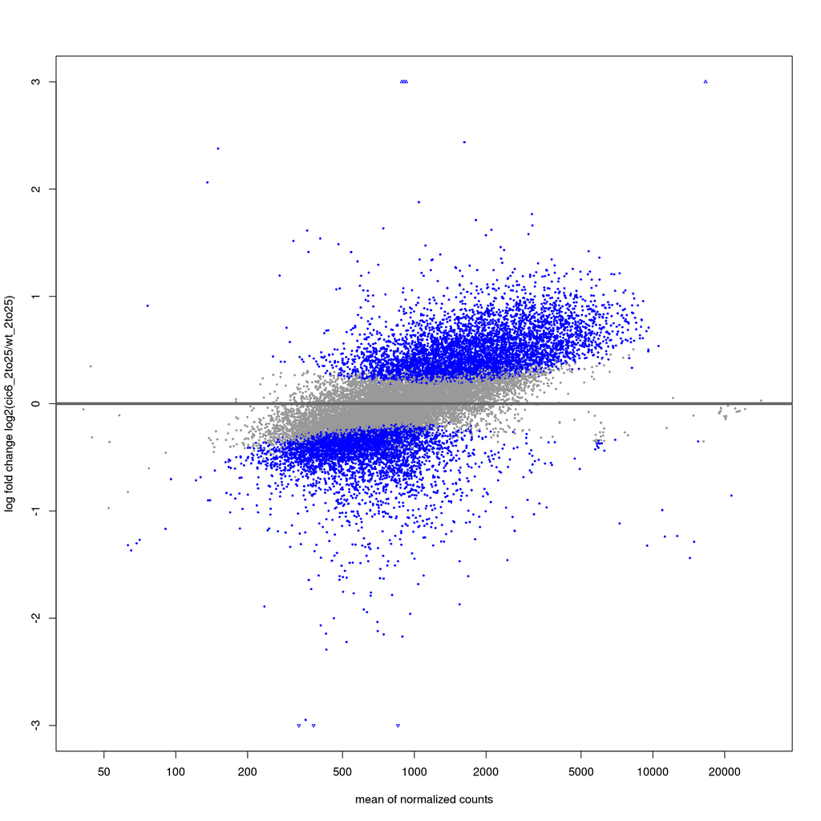

```r
t3_res.cic6.df <- results(model_cic6, contrast = c("condition","cic6_2to25","wt_2to25"), alpha = 0.05)
plotMA(t3_res.cic6.df, ylim=c(-3,3), ylab = 'log fold change log2(cic6_2to25/wt_2to25)')
```

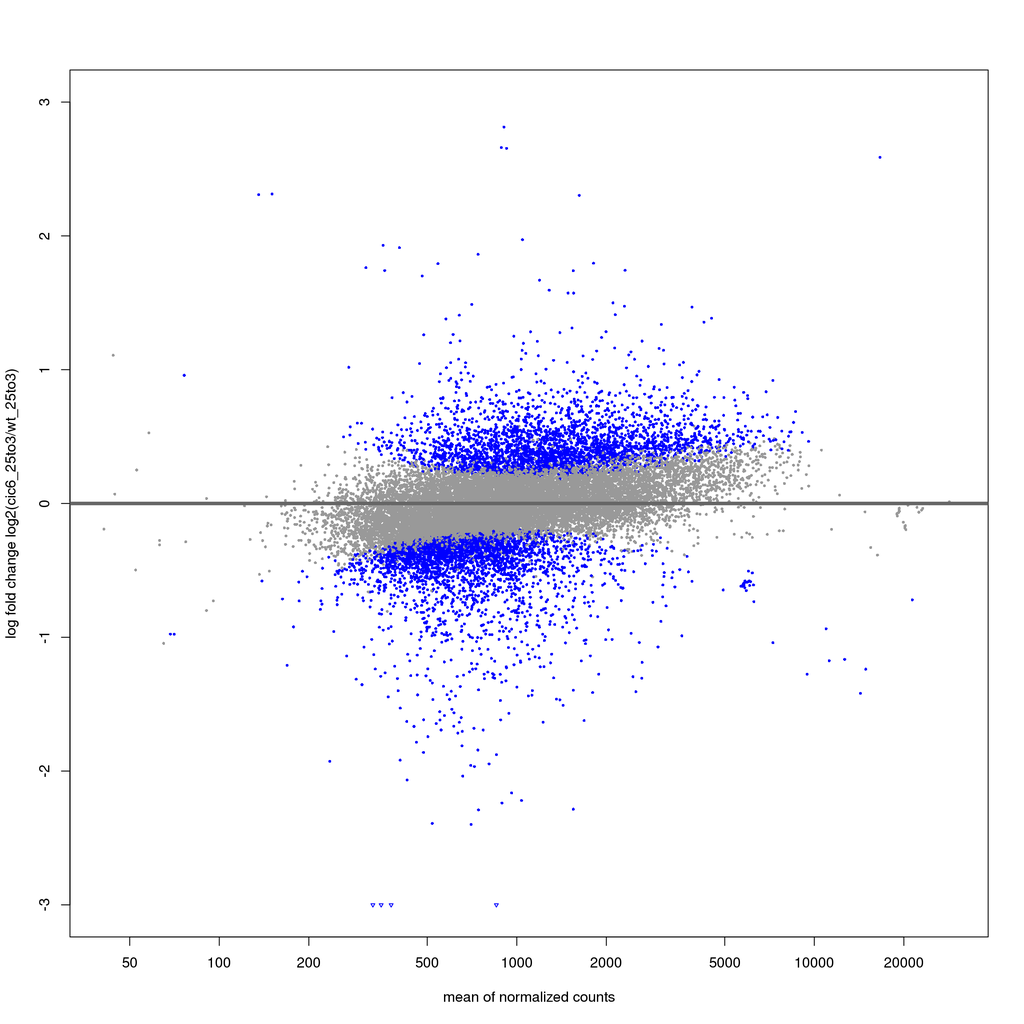

```r
t3.cic.ma <- ggplot(as.data.frame(t3_res.cic6.df), aes(x = baseMean, y = log2FoldChange))+
  geom_hline(yintercept = 0, color = 'black', linetype = 'dotted')+
  geom_point(aes(color = padj <0.05), size = .2) +
  #geom_point(color = 'gray', size = .2) +
  scale_y_continuous(limits = c(-3, 3), name = 'log2(cic6_2to25/wt_2to25)')+
  scale_x_continuous(limits = c(0,10000), breaks = c(0,2000,4000,6000,8000,10000))+
  xlab("Mean normalized ATAC-seq signal") +
  ggtitle("MA plot at 2-2.5 hr") +
  theme_cowplot()

t4_res.cic6.df <- results(model_cic6, contrast = c("condition","cic6_25to3","wt_25to3"), alpha = 0.05)
plotMA(t4_res.cic6.df, ylim=c(-3,3), ylab = 'log fold change log2(cic6_25to3/wt_25to3)')
```

```r
t4.cic.ma <- ggplot(as.data.frame(t4_res.cic6.df), aes(x = baseMean, y = log2FoldChange))+
  geom_hline(yintercept = 0, color = 'black', linetype = 'dotted')+
  geom_point(aes(color = padj <0.05), size = .2) +
  #geom_point(color = 'gray', size = .2) +
  scale_y_continuous(limits = c(-3, 3), name = 'log2(cic6_25to3/wt_25to3)')+
  scale_x_continuous(limits = c(0,10000), breaks = c(0,2000,4000,6000,8000,10000))+
  xlab("Mean normalized ATAC-seq signal") +
  ggtitle("MA plot at 2.5-3 hr") +
  theme_cowplot()

maplots.cic <- t3.cic.ma + t4.cic.ma
ggsave("cic6_effect_ma_plots.pdf", plot = maplots.cic, path = "figures/16_capicua_depletion_atac/", width = 25, height = 10, units = "cm")
ggsave("cic6_effect_ma_plots.png", plot = maplots.cic, path = "figures/16_capicua_depletion_atac/", width = 25, height = 10, units = "cm")
```

## 4.4. Plot results at enhancers

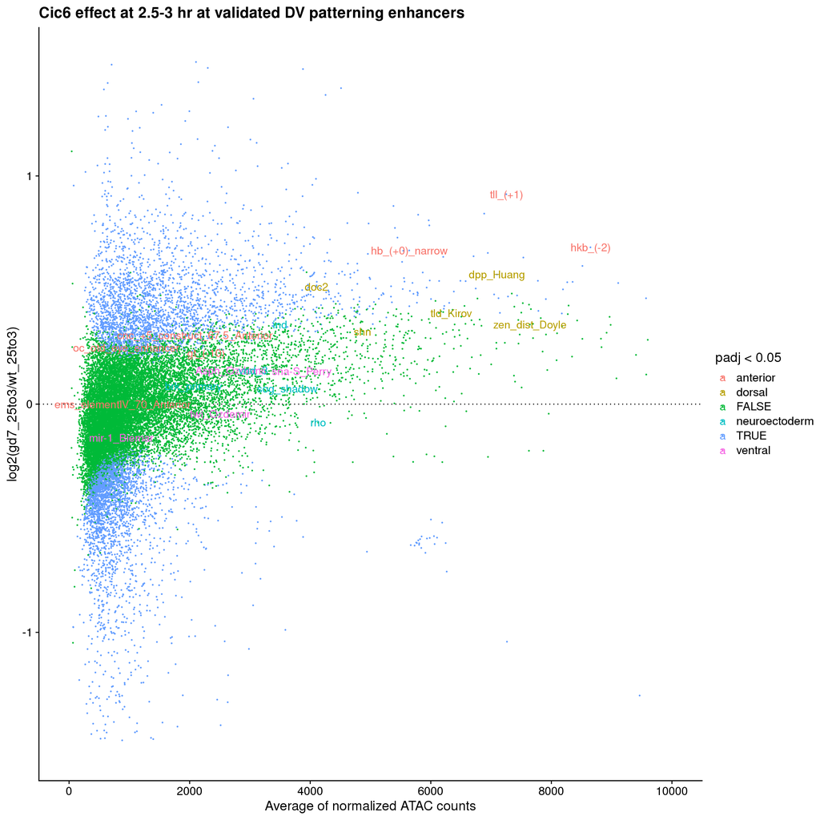

```r
# Import enhancers  list that contains some DV and AP enhancers that we manually parsed down from larger enhancer lists (Cusanovich, Koenecke, Zeitlinger) for ease of viewing.

dv_enhancers_subset.gr <- read.csv(file = '/l/Zeitlinger/ZeitlingerLab/Manuscripts/Zelda_and_Nucleosomes/Analysis/analysis/bed/enhancers/dv_enhancers_subset.csv', header = TRUE) %>% makeGRangesFromDataFrame(keep.extra.columns = TRUE)

# Join ATAC peaks with enhancers

peaks.gr$enhancer_name <- NA
enhancer.ov <- findOverlaps(peaks.gr, dv_enhancers_subset.gr, ignore.strand = T)
peaks.gr$enhancer_name[enhancer.ov@from]<-dv_enhancers_subset.gr$name[enhancer.ov@to]

# Add patterning information

peaks.gr$pattern <- NA
peaks.gr$pattern[enhancer.ov@from]<-dv_enhancers_subset.gr$pattern[enhancer.ov@to]

#Join with DE results (I used the 4th timepoint because this is the timepoint I previoulsy used for Dorsal)

peaks_w_de.df <- cbind(peaks.gr %>% as.data.frame, t4_res.cic6.df) %>%
  dplyr::mutate(has_enhancer = ifelse(is.na(enhancer_name), 'no','yes'))

#Plot with DE results

cic6_names_to_show <- c("sog_shadow", "brk_primary", "rho", "vnd_3", "twi_Ozdemir", "Asph_Ozdemir", "sna-S_Perry", "mir-1_Biemar", "tld_Kirov", "zen_dist_Doyle", "dpp_Huang", "shn", "doc2", "hkb_(-2)", "hb_(+0)_narrow", "tll_(+1)", "cnc_+5_construct_67.5_Anterior", "ems_elementIV_70_Anterior", "ind", "gt_(-10)", "oc_otd_eye_enhancer")

cic6_effect_at_dv_enhancers <- ggplot(peaks_w_de.df, aes(x = baseMean, y = log2FoldChange))+
  geom_hline(yintercept = 0, color = 'black', linetype = 'dotted')+
  geom_point(aes(color = padj <0.05), size = .2) +
  geom_text(data = peaks_w_de.df[peaks_w_de.df$enhancer_name %in% cic6_names_to_show,],aes(label = enhancer_name, color = pattern), size = 4)+
  scale_y_continuous(limits = c(-1.5, 1.5), name = 'log2(gd7_25to3/wt_25to3)')+
  scale_x_continuous(limits = c(0,10000), breaks = c(0,2000,4000,6000,8000,10000))+
  xlab("Average of normalized ATAC counts") +
  ggtitle("Cic6 effect at 2.5-3 hr at validated DV patterning enhancers") +
  theme_cowplot()
cic6_effect_at_dv_enhancers
```

```r
ggsave("cic6_effect_at_dv_enhancers_25to3_w_signif.pdf", plot = cic6_effect_at_dv_enhancers, path = "figures/16_capicua_depletion_atac/", width = 25, height = 20, units = "cm")
ggsave("cic6_effect_at_dv_enhancers_25to3_w_signif.png", plot = cic6_effect_at_dv_enhancers, path = "figures/16_capicua_depletion_atac/", width = 25, height = 20, units = "cm")

# Print padj values

peaks_w_de.df[!is.na(peaks_w_de.df$enhancer_name),][peaks_w_de.df[!is.na(peaks_w_de.df$enhancer_name),]$enhancer_name %in% cic6_names_to_show, c(7,8,13,14)]
```

```
##                        enhancer_name       pattern       pvalue         padj
## 359                        dpp_Huang        dorsal 1.049676e-03 6.382212e-03
## 2421                     sna-S_Perry       ventral 3.086426e-01 4.812985e-01
## 3218                    mir-1_Biemar       ventral 1.305673e-01 2.639972e-01
## 5535                             shn        dorsal 2.823427e-02 8.620162e-02
## 6265                    Asph_Ozdemir       ventral 3.118172e-01 4.848513e-01
## 7290                     twi_Ozdemir       ventral 7.803959e-01 8.686048e-01
## 7820                             rho neuroectoderm 6.273932e-01 7.607133e-01
## 8954                            doc2        dorsal 1.419555e-03 8.168879e-03
## 9953                             ind neuroectoderm 5.628214e-02 1.443247e-01
## 12780                       hkb_(-2)      anterior 4.123961e-07 6.890274e-06
## 13162                 zen_dist_Doyle        dorsal 3.965461e-02 1.113275e-01
## 13468                 hb_(+0)_narrow      anterior 2.770407e-04 2.084776e-03
## 14257      ems_elementIV_70_Anterior      anterior 9.976035e-01 9.991713e-01
## 15656 cnc_+5_construct_67.5_Anterior      anterior 1.503795e-02 5.326893e-02
## 15882                      tld_Kirov        dorsal 1.832366e-02 6.176234e-02
## 16770                       tll_(+1)      anterior 1.728095e-08 3.812190e-07
## 17269                          vnd_3 neuroectoderm 3.066413e-01 4.792475e-01
## 17514                       gt_(-10)      anterior 1.294402e-01 2.622501e-01
## 18307                    brk_primary neuroectoderm 6.167008e-01 7.530699e-01
## 18525            oc_otd_eye_enhancer      anterior 6.088916e-02 1.526056e-01
## 19654                     sog_shadow neuroectoderm 6.905862e-01 8.061680e-01
```

## 4.5. Map DESeq2 results back to peaks

```r
# overlap with peaks

peaks_w_de_t3.df <- cbind(peaks.gr %>% as.data.frame, t3_res.cic6.df) %>%
  dplyr::mutate(has_enhancer = ifelse(is.na(enhancer_name), 'no','yes'))
peaks_w_de_t4.df <- cbind(peaks.gr %>% as.data.frame, t4_res.cic6.df) %>%
  dplyr::mutate(has_enhancer = ifelse(is.na(enhancer_name), 'no','yes'))

# make GRanges for export

peaks_w_de_t3.gr <- peaks_w_de_t3.df %>%
  dplyr::mutate(timepoint = '2to25') %>%
  makeGRangesFromDataFrame(keep.extra.columns = TRUE)

peaks_w_de_t4.gr <- peaks_w_de_t4.df %>%
  dplyr::mutate(timepoint = '25to3') %>%
  makeGRangesFromDataFrame(keep.extra.columns = TRUE)
```

## 4.6. Save DESeq2 results

```r
deseq_at_peaks.list <- list('cic6_2to25/wt_2to25' = peaks_w_de_t3.gr,
                            'cic6_25to3/wt_25to3' = peaks_w_de_t4.gr)
saveRDS(deseq_at_peaks.list, '/l/Zeitlinger/ZeitlingerLab/Manuscripts/Zelda_and_Nucleosomes/Analysis/data/deseq2/cic6/deseq_timepoints_at_orer_2to3_atac_peaks.RData')
```

## 4.7. Export DESeq2 results as .txt file for GEO

```r
peaks_w_de_t3.df <- as.data.frame(peaks_w_de_t3.gr)
peaks_w_de_t3.df$deseq <- "cic6_2to25/wt_2to25"
peaks_w_de_t4.df <- as.data.frame(peaks_w_de_t4.gr)
peaks_w_de_t4.df$deseq <- "cic6_25to3/wt_25to3"

all_cic_deseq.df <- rbind(peaks_w_de_t3.df,peaks_w_de_t4.df)

write.table(all_cic_deseq.df,'/l/Zeitlinger/ZeitlingerLab/Manuscripts/Zelda_and_Nucleosomes/Analysis/data/deseq2/cic6/cic6_deseq_timepoints_at_orer_2to3_atac_peaks.txt', row.names=FALSE)
```

# 5. Plot Wt, Zld-, gd7, and cic6 data at individual enhancers from both AP and DV axes to compare individual well-studied enhancers

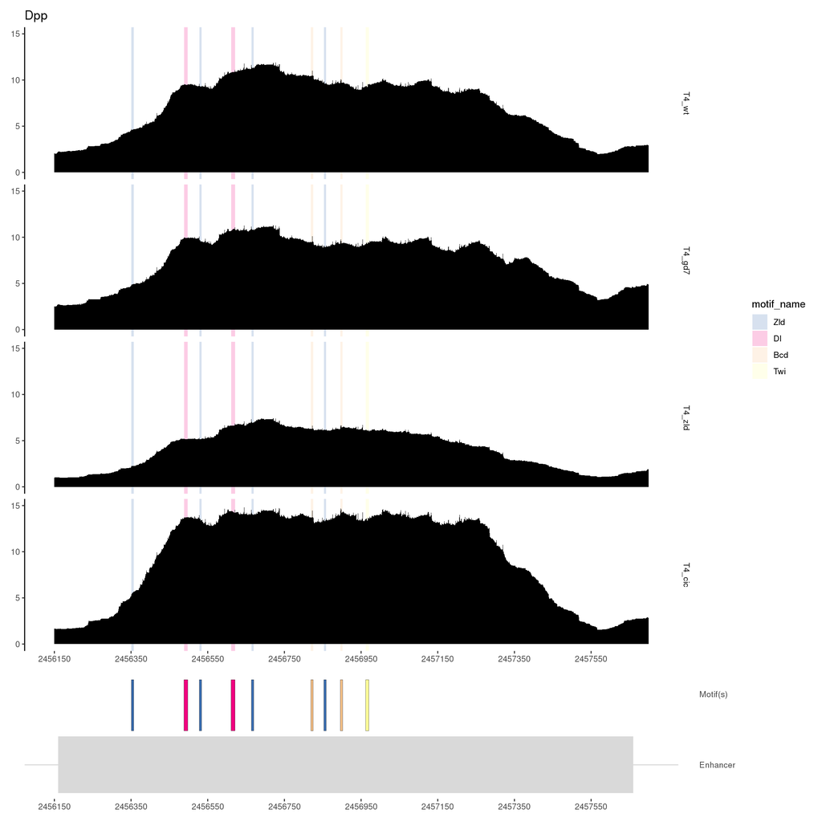

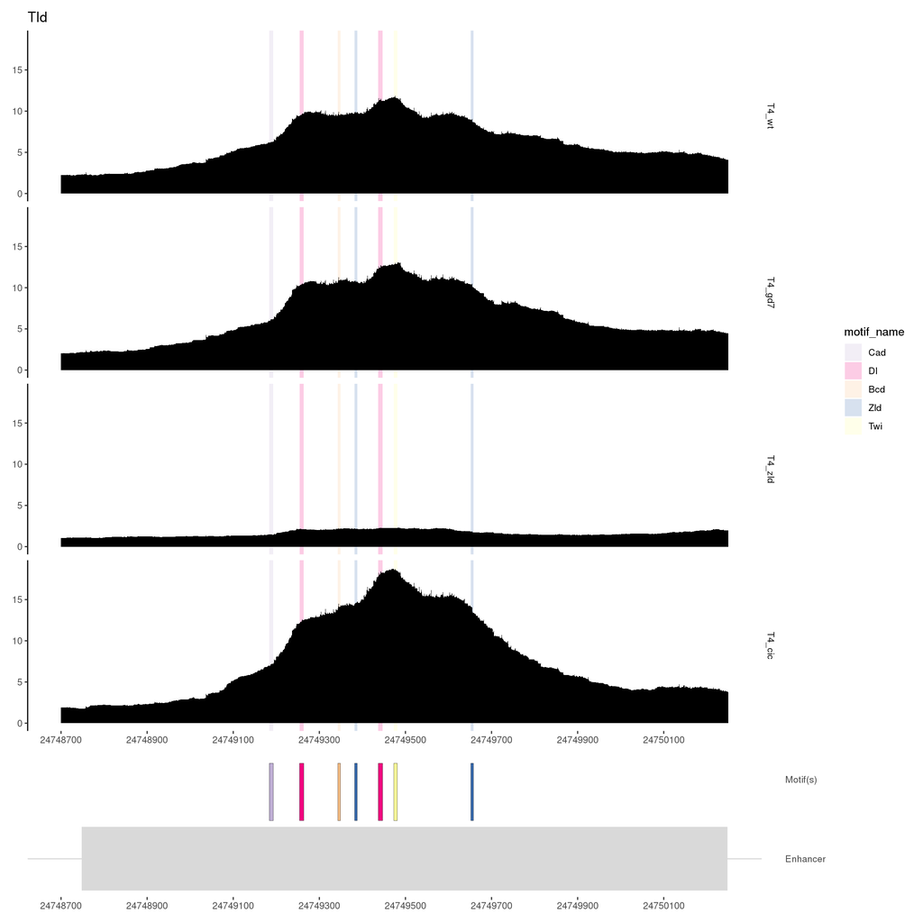

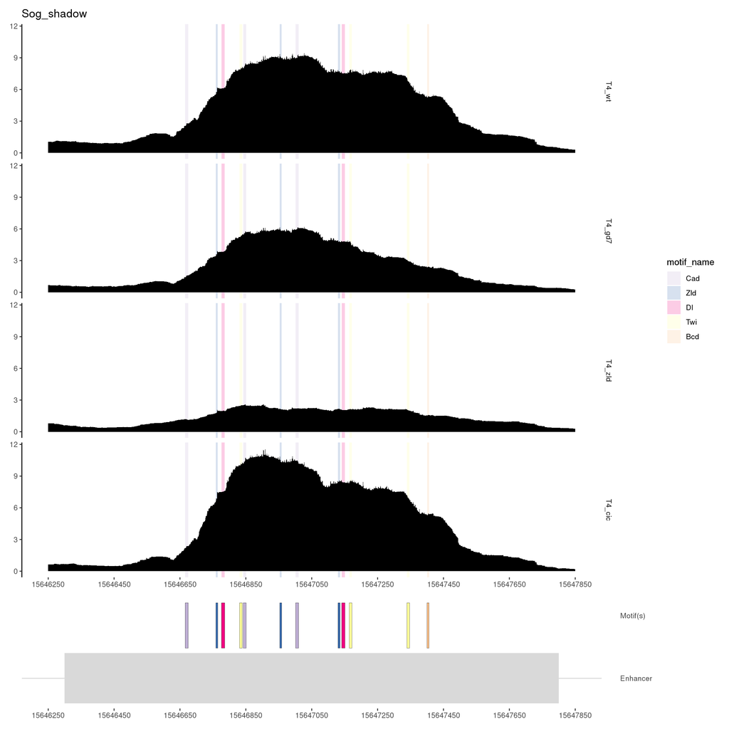

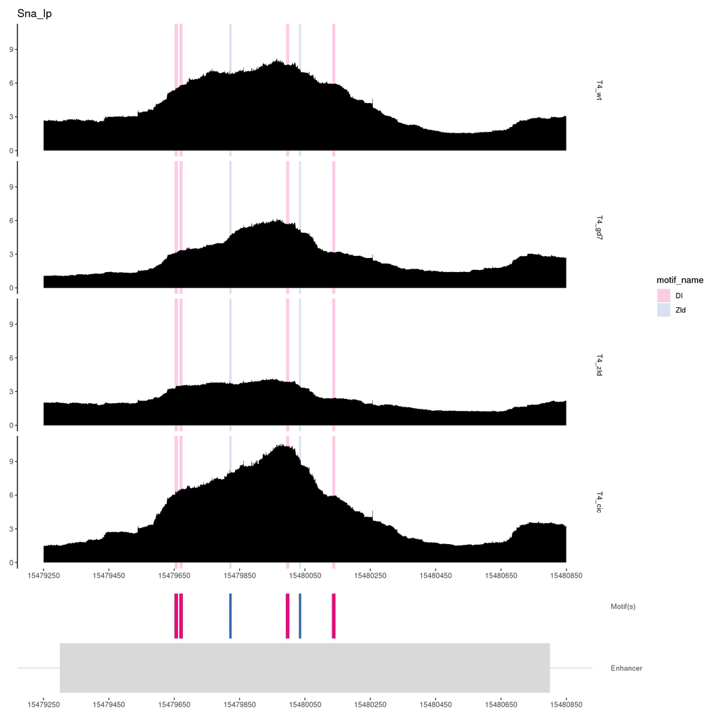

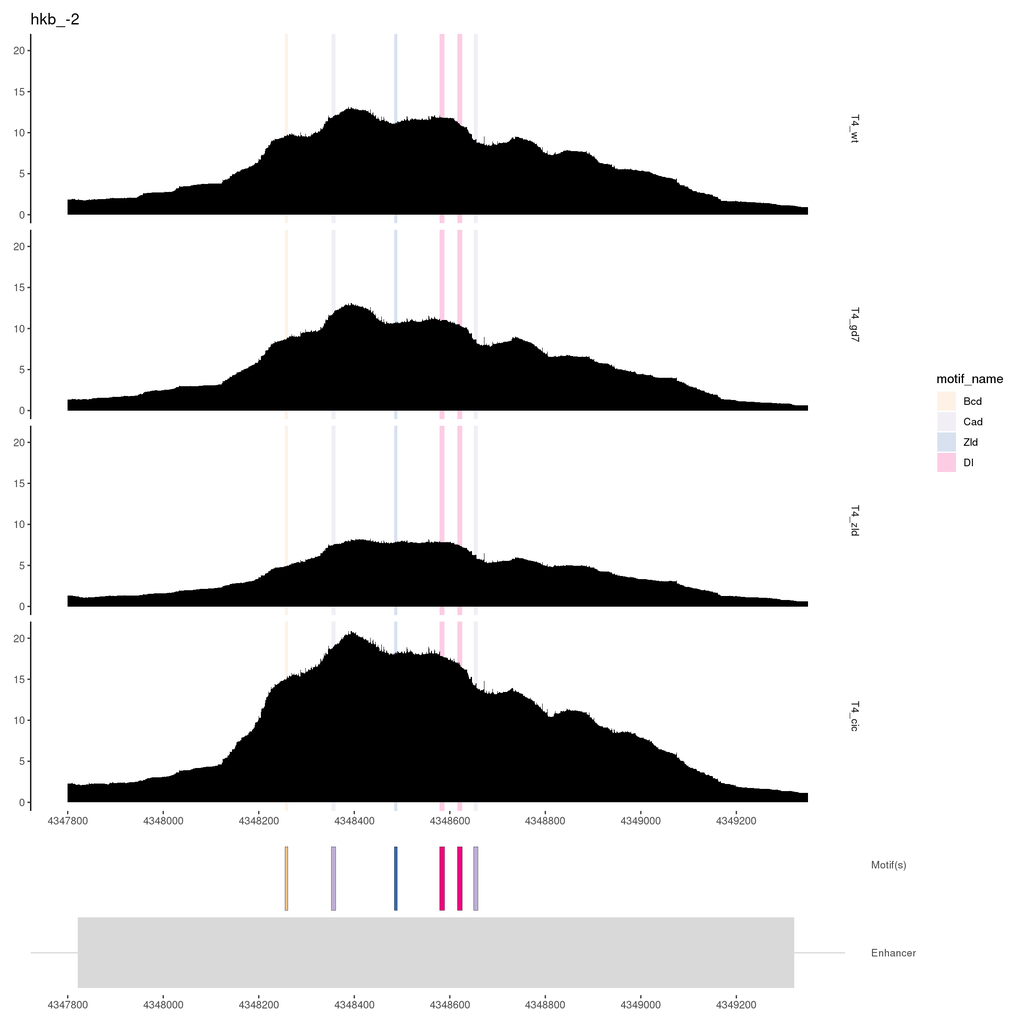

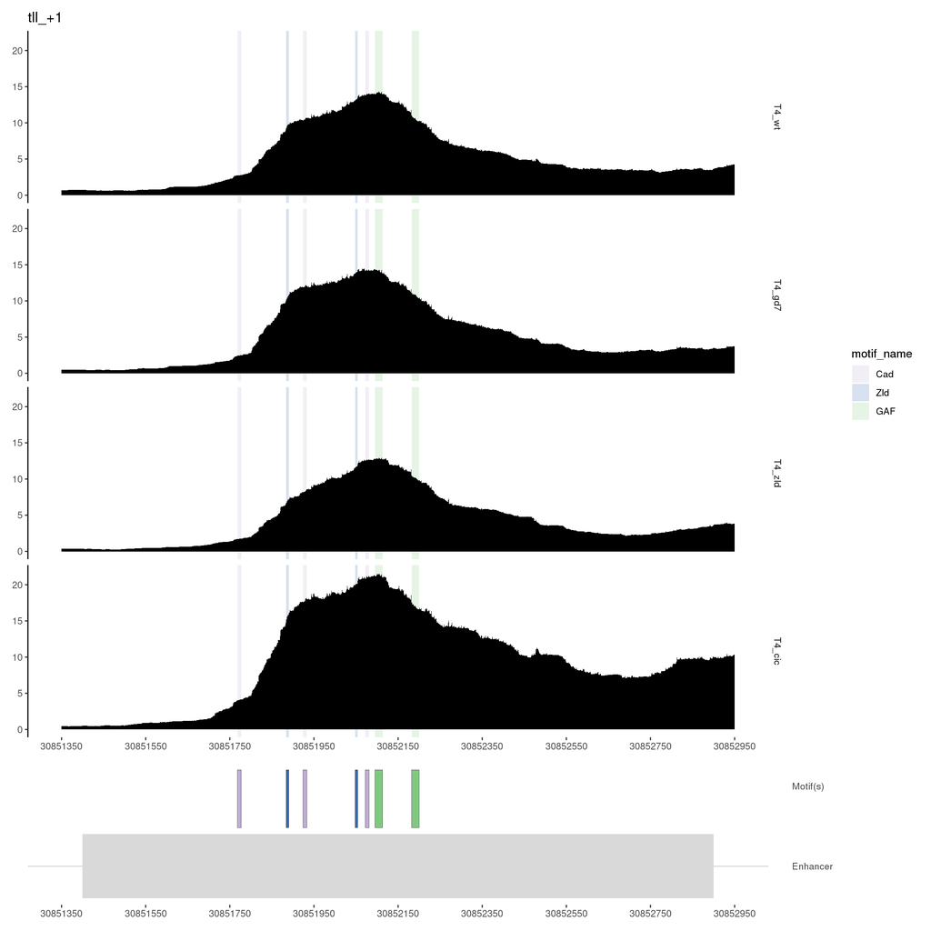

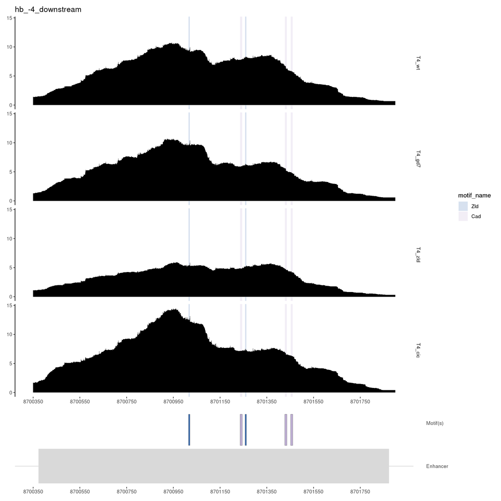

```r
# Define enhancers

enhancers.gr<-c(
  GRanges('chr2L', IRanges(start = 2456160, end = 2457660), strand = '*', name = 'Dpp'),
  GRanges('chr3R', IRanges(start = 24748748, end = 24750248), strand = '*', name = 'Tld'),
  GRanges('chrX', IRanges(start = 15646300, end = 15647800), strand = '*', name = 'Sog_shadow'),
  GRanges('chr2L', IRanges(start = 15479300, end = 15480800), strand = '*', name = 'Sna_lp'),
  GRanges('chr3R', IRanges(start = 4347821, end = 4349321), strand = '*', name = 'hkb_-2'),
  GRanges('chr3R', IRanges(start = 30851400, end = 30852900), strand = '*', name = 'tll_+1'),
  GRanges('chr3R', IRanges(start = 8700373, end = 8701873), strand = '*', name = 'hb_-4_downstream'))

# Make bw coverage list with all strains

bw.list<-list(`T4_wt` = '/l/Zeitlinger/ZeitlingerLab/Manuscripts/Zelda_and_Nucleosomes/Analysis/data/bw/dm6/atac/combined/orer_25to3_atac_combined_normalized.bw',
              `T4_gd7` = '/l/Zeitlinger/ZeitlingerLab/Manuscripts/Zelda_and_Nucleosomes/Analysis/data/bw/dm6/atac/combined/gd7_25to3_atac_combined_normalized.bw',
              `T4_zld` = '/l/Zeitlinger/ZeitlingerLab/Manuscripts/Zelda_and_Nucleosomes/Analysis/data/bw/dm6/atac/combined/zldrnai_25to3_atac_combined_normalized.bw',
              `T4_cic` = '/l/Zeitlinger/ZeitlingerLab/Manuscripts/Zelda_and_Nucleosomes/Analysis/data/bw/dm6/atac/combined/cic6_25to3_atac_combined_normalized.bw')

# Process motifs

motifs.gr<-readr::read_tsv('/l/Zeitlinger/ZeitlingerLab/Manuscripts/Zelda_and_Nucleosomes/Analysis/analysis/tsv/mapped_motifs/all_instances_curated_1based.tsv.gz') %>%
  makeGRangesFromDataFrame(keep.extra.columns = T, starts.in.df.are.0based = F) %>%
  plyranges::mutate(motif = pattern_name,
                    name = pattern_name) %>%
  GenomicRanges::sort(ignore.strand = T)

#Specific variables
library(RColorBrewer)
n_motifs<-motifs.gr$name %>% unique %>% length
colors <- colorRampPalette(brewer.pal(n_motifs, "Accent"))(n_motifs)
# getPalette(colourCount)
# getPalette = colorRampPalette(brewer.pal(n_motifs, "Set1"))
#
# many_colors <- grDevices::colors()[grep('gr(a|e)y|white', grDevices::colors(), invert = T)]
# many_colors <- many_colors[20:(length(many_colors)-20)]
# step<-floor(length(many_colors) / n_motifs)
# colors <- many_colors[seq(1, n_motifs*step, step)]
names(colors)<-motifs.gr$name %>% unique
motif.colors.list<-as.list(colors)

# Function

plot_coverage_and_enhancer<-function(enhancer.gr, motifs.gr, bw.list, motif.colors.list, title, region_width = 1000,
                                     cores = 6, scales = 'fixed', rounding_margin = 50, label_margin = 200){

  #Assertion requirements to make the function run correctly.
  testit::assert("Input enhancer GRanges needs to contain only 1 region.", length(enhancer.gr)==1)
  testit::assert("Motifs need to be a GRanges object", is(motifs.gr, "GRanges"))
  testit::assert("Enhancers need to be a GRanges object", is(enhancer.gr, "GRanges"))
  testit::assert("Region width should be larger than enhancer width.", width(enhancer.gr)<=region_width)
  testit::assert("Bigwig object needs to be a list of samples. If samples are ChIP-nexus/double-stranded samples, they need to be in a nested list.",
                 is(bw.list, "list") & all(!(names(bw.list) %in% c("pos", "neg"))))
  testit::assert("Motif object needs a column titled pattern_name, motif_name, or name to distinguish motifs apart.",
                 any(grepl("pattern_name|name|motif_name", colnames(motifs.gr@elementMetadata))))

  #Find overlaps between motif set and enhancer
  motifs_in_enhancer.gr<-subsetByOverlaps(motifs.gr, resize(enhancer.gr, region_width, "center"), ignore.strand = T)
  if("pattern_name" %in% colnames(motifs_in_enhancer.gr@elementMetadata)){
    motifs_in_enhancer.gr$motif_name<-motifs_in_enhancer.gr$pattern_name
  }
  if("name" %in% colnames(motifs_in_enhancer.gr@elementMetadata)){
    motifs_in_enhancer.gr$motif_name<-motifs_in_enhancer.gr$name
  }

  #Extract colors for enhancer
  fills_in_order<-lapply(motifs_in_enhancer.gr$motif_name, function(x) motif.colors.list[[x]]) %>% unlist %>% unique %>% as.character
  motifs_in_order<-motifs_in_enhancer.gr$motif_name %>% unique %>% as.character
  motifs_in_enhancer.df<-motifs_in_enhancer.gr %>% as.data.frame
  motifs_in_enhancer.df$motif_name<-factor(motifs_in_enhancer.df$motif_name, levels = motifs_in_order)

  #Convert enhancer coordinates to df
  enhancer.df<-enhancer.gr %>% as.data.frame

  #Get half of the enhancer
  enh_half<-floor(width(enhancer.gr)/2)
  lower_bounds<-plyr::round_any(enhancer.df$start - (region_width/2 - enh_half), rounding_margin, f = floor)
  upper_bounds<-plyr::round_any(enhancer.df$end + (region_width/2 - enh_half), rounding_margin, f = ceiling)

  enhancer.plot<-ggplot()+
    geom_hline(yintercept = .5, color = "gray 85")+
    geom_rect(data = enhancer.df, aes(xmin = start, xmax = end, ymin = 0, ymax = 1), fill = "gray 85")+
    geom_text(data = enhancer.df, aes(x = ((start - end)/2 + start), y = .5, label = paste0(seqnames, ":", start, "-", end)),
              color = "black")
  if(nrow(motifs_in_enhancer.df)>0){
    enhancer.plot<-enhancer.plot + geom_rect(data = motifs_in_enhancer.df,
                                             aes(xmin = start, xmax = end, ymin = 1.1, ymax = 2, fill = motif_name), color = 'black', size = .1)
  }
  enhancer.plot<-enhancer.plot+
    scale_fill_manual(values = fills_in_order)+
    scale_x_continuous(breaks = seq(plyr::round_any(enhancer.df$start - (region_width/2 - enh_half), rounding_margin, f = floor),
                                    plyr::round_any(enhancer.df$end + (region_width/2 - enh_half), rounding_margin, f = ceiling), label_margin),
                       limits = c(lower_bounds,upper_bounds))+
    scale_y_continuous(breaks = c(.5, 1.75), labels = c("Enhancer", "Motif(s)"), position = "right")+
    theme_classic()+
    theme(axis.title = element_blank(), axis.line = element_blank(), axis.ticks.y = element_blank(),
          legend.position = "none")

  # Get coverage across bigwig list
  coverage.df<-mclapply(names(bw.list), function(x){
    if(length(bw.list[[x]])==1){
      df<-standard_metapeak(resize(enhancer.gr, 1, "center"), bw.list[[x]], upstream = floor(region_width/2) + rounding_margin, downstream = floor(region_width/2)+300) %>%
        dplyr::rename(window_distance = tss_distance) %>%
        dplyr::mutate(position = window_distance + start(resize(enhancer.gr, 1, "center")), sample_name = x)
    }
    if(length(bw.list[[x]])==2){
      df<-exo_metapeak(resize(enhancer.gr, 1, "center"), bw.list[[x]], upstream = region_width/2 + rounding_margin, downstream = region_width/2+rounding_margin) %>%
        dplyr::rename(window_distance = tss_distance) %>%
        dplyr::mutate(position = window_distance + start(enhancer.gr), sample_name = x)
    }
    return(df)
  }, mc.cores = cores) %>% rbindlist() %>%
    dplyr::filter(position >= lower_bounds, position <= upper_bounds) %>%
    dplyr::mutate(sample_name = factor(sample_name, levels = names(bw.list)))

  #Check for strand if there are no 2-channeled samples.
  if(!("strand" %in% colnames(coverage.df))){
    coverage.df$strand<-NA
  }

  #Plot the enhancer coverage.
  coverage.plot<-ggplot(coverage.df)
  if(nrow(motifs_in_enhancer.df)>0){
    coverage.plot<-coverage.plot + geom_rect(data = motifs_in_enhancer.df, aes(xmin = start, xmax = end, ymin = -Inf, ymax = Inf, fill = motif_name), alpha = .2)
  }
  coverage.plot<-coverage.plot +
    geom_area(aes(x = position, y = reads, group = strand), fill = "black")+
    geom_text(aes(x = Inf, y = Inf, label = sample_name), hjust = -.01)+
    scale_fill_manual(values = fills_in_order)+
    scale_x_continuous(breaks = seq(plyr::round_any(enhancer.df$start - (region_width/2 - enh_half), rounding_margin, f = floor),
                                    plyr::round_any(enhancer.df$end + (region_width/2 - enh_half), rounding_margin, f = ceiling), label_margin),
                       limits = c(lower_bounds,upper_bounds))+
    facet_grid(sample_name ~ ., scales = scales)+
    ggtitle(title)+
    theme_classic()+
    theme(axis.title = element_blank(), axis.line.x = element_blank(), strip.background = element_blank())

  g<-coverage.plot + enhancer.plot + plot_layout(ncol = 1, heights = c(5, 1))
  return(g)
}

# Plot regions

mclapply(1:length(enhancers.gr), function(x){
  enhancer.gr = enhancers.gr[x]
  g<-plot_coverage_and_enhancer(enhancer.gr = enhancer.gr, motifs.gr = motifs.gr, bw.list = bw.list,
                                motif.colors.list = motif.colors.list, title = enhancer.gr$name,
                                region_width = width(enhancer.gr), cores = 6, scales = 'fixed')
  ggsave(paste0("figures/16_capicua_depletion_atac/", enhancer.gr$name,"_single_example.pdf"), g, height = 15, width = 20)
  ggsave(paste0("figures/16_capicua_depletion_atac/", enhancer.gr$name,"_single_example.png"), g, height = 15, width = 20)
  return(g)
}, mc.cores = 4)
```

## 5.1 Plot the same regions but with 2-2.5 hr AEL data as a supplemental figure

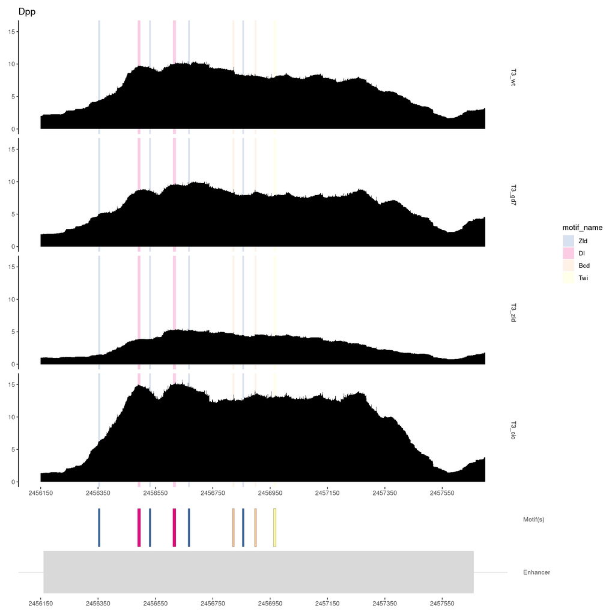

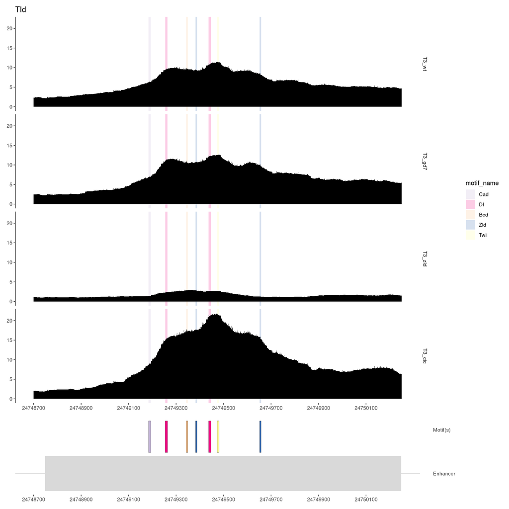

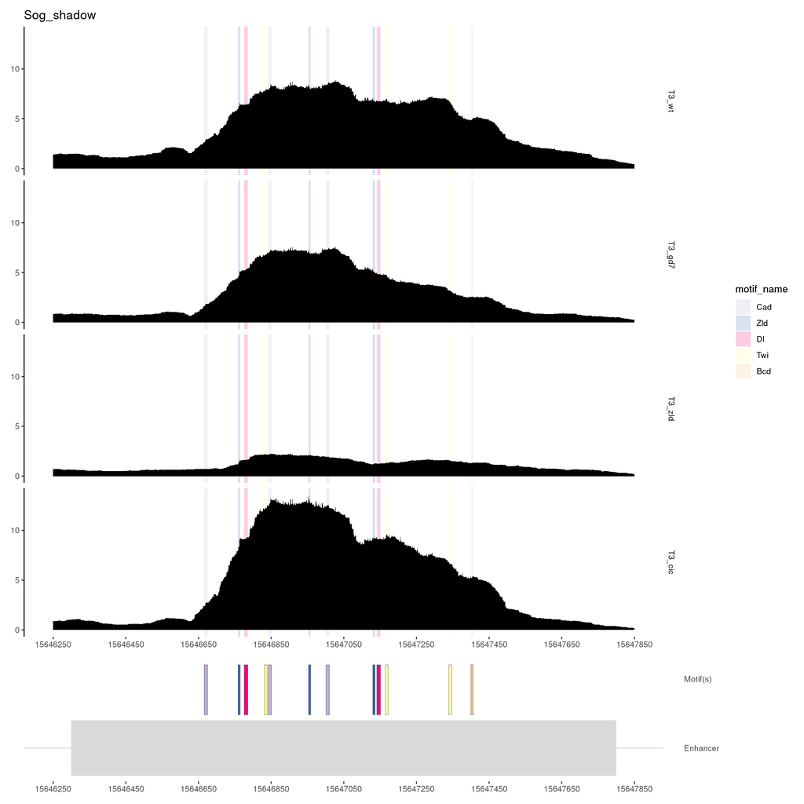

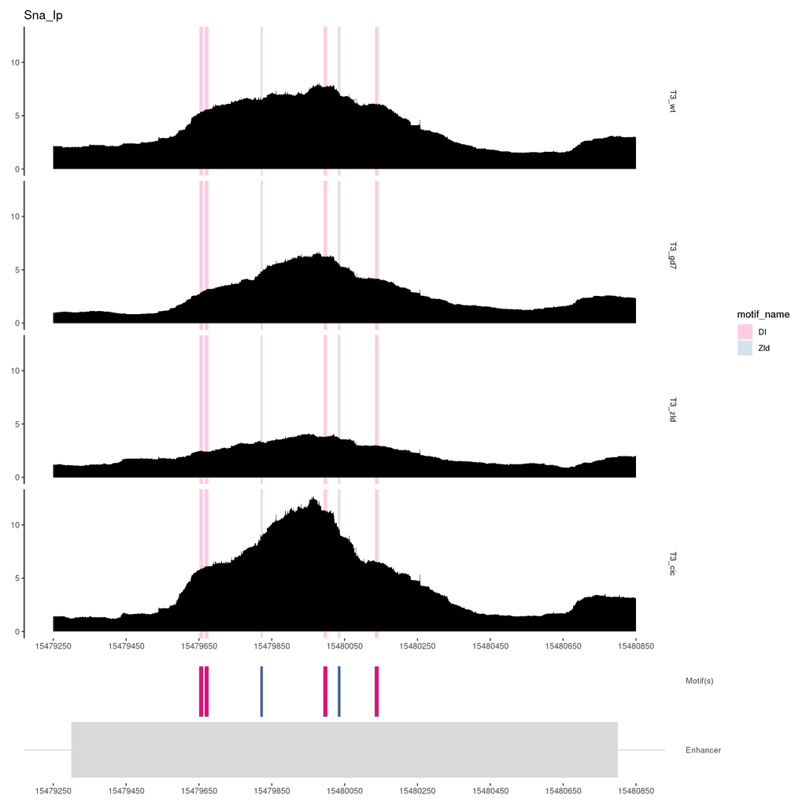

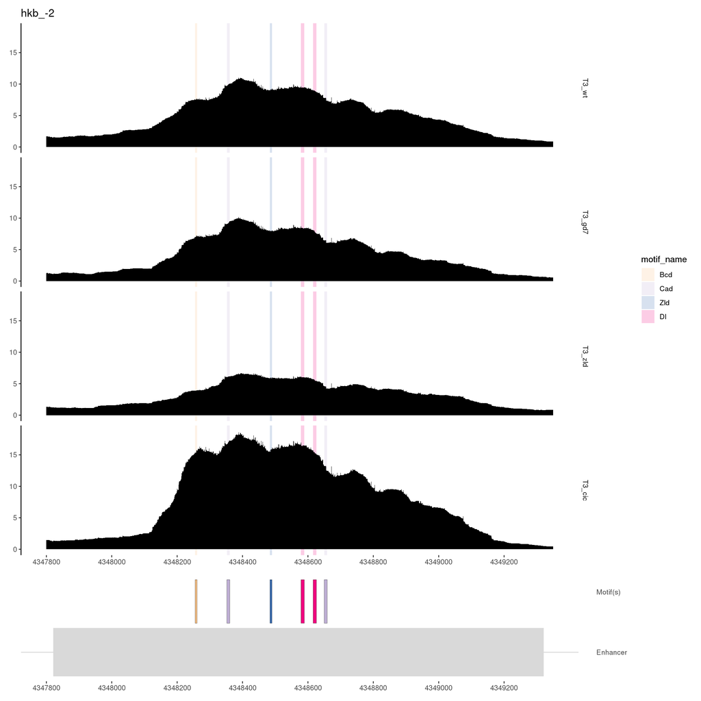

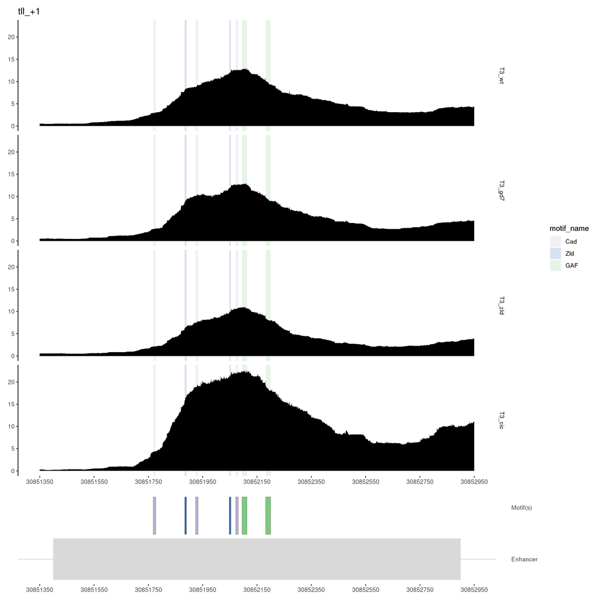

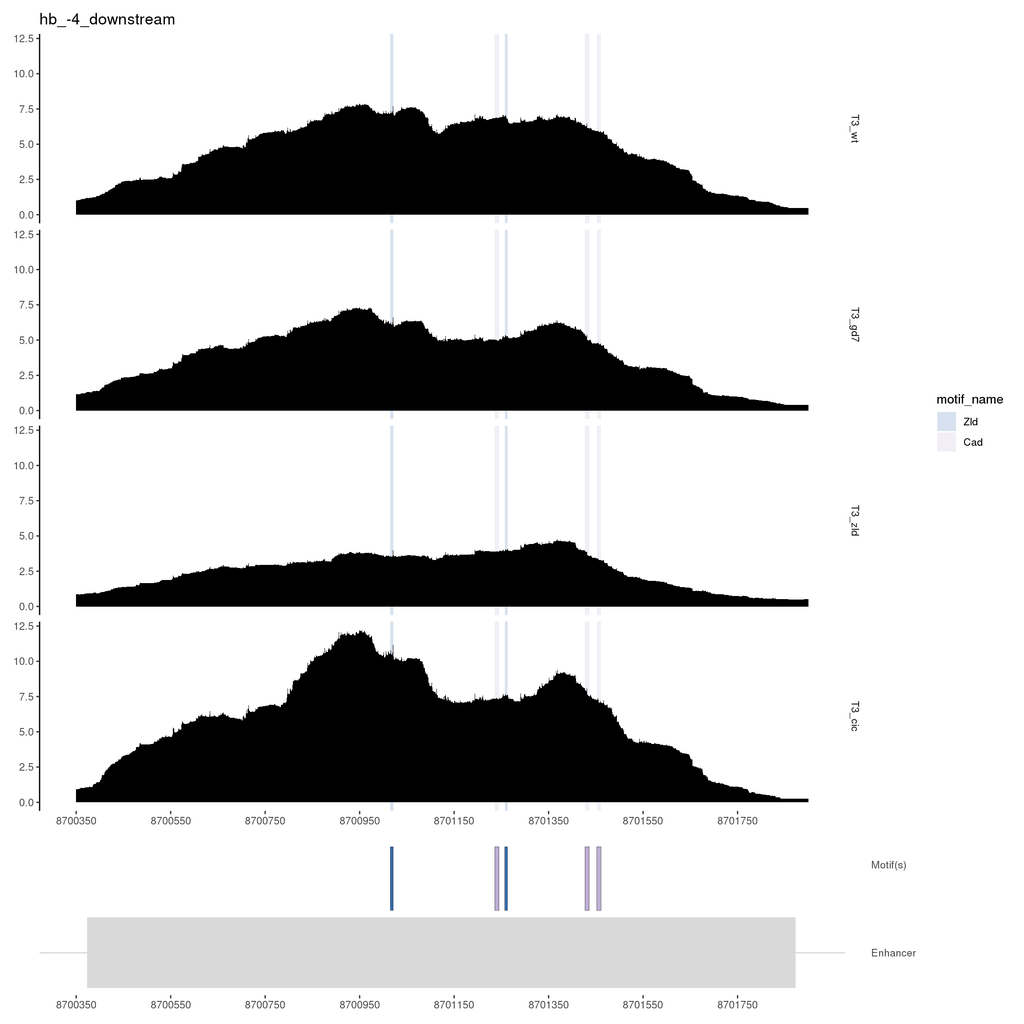

```r
t3.bw.list<-list(`T3_wt` = '/l/Zeitlinger/ZeitlingerLab/Manuscripts/Zelda_and_Nucleosomes/Analysis/data/bw/dm6/atac/combined/orer_2to25_atac_combined_normalized.bw',
              `T3_gd7` = '/l/Zeitlinger/ZeitlingerLab/Manuscripts/Zelda_and_Nucleosomes/Analysis/data/bw/dm6/atac/combined/gd7_2to25_atac_combined_normalized.bw',
              `T3_zld` = '/l/Zeitlinger/ZeitlingerLab/Manuscripts/Zelda_and_Nucleosomes/Analysis/data/bw/dm6/atac/combined/zldrnai_2to25_atac_combined_normalized.bw',
              `T3_cic` = '/l/Zeitlinger/ZeitlingerLab/Manuscripts/Zelda_and_Nucleosomes/Analysis/data/bw/dm6/atac/combined/cic6_2to25_atac_combined_normalized.bw')

# Plot regions

mclapply(1:length(enhancers.gr), function(x){
  enhancer.gr = enhancers.gr[x]
  g<-plot_coverage_and_enhancer(enhancer.gr = enhancer.gr, motifs.gr = motifs.gr, bw.list = t3.bw.list,
                                motif.colors.list = motif.colors.list, title = enhancer.gr$name,
                                region_width = width(enhancer.gr), cores = 6, scales = 'fixed')
  ggsave(paste0("figures/16_capicua_depletion_atac/", enhancer.gr$name,"_t3_single_example.pdf"), g, height = 15, width = 20)
  ggsave(paste0("figures/16_capicua_depletion_atac/", enhancer.gr$name,"_t3_single_example.png"), g, height = 15, width = 20)
  return(g)
}, mc.cores = 4)
```